# Drones

Jill Walker Rettberg

University of Bergen

09 May, 2022

How are drones portrayed in contemporary art and fiction? This paper uses data from a dataset that documents and analyses representations of machine vision technologies in 500 creative works, including digital artworks, video games and science fiction novels and movies.

## To do:

- check whether some verbs are only used with one technology. Could do a boxplot?
- GROUP verbs - either using clustering from other script, or manually. Colour by group.
- What sentiments and topics are typically used with drones? Any other characteristics of the creative works?
- Timeline?
- Do characters who are in a situation with drones have particular traits? To find out, I need to figure out how to identify characters that are in a situation that ALSO has drones in it. Do I group by SituationID - and then what?

```r
suppressMessages(library(tidyverse))

# The following may be more than needed - it's from machinevisionscripts.R.

CreativeWorks <- read_csv("../data/creativeworks.csv",
                          locale = locale(encoding = "UTF-8"),
        col_types = cols(
                WorkID = col_integer(),
                WorkTitle = col_character(),
                Sentiment = col_factor(levels = c(
                        "Exciting", "Flawed", "Helpful", "Neutral", "Wondrous",
                        "Hostile","Oppressive", "Alien", "Creepy", "Subversive",
                        "Dangerous",  "Intrusive", "Empowering", "Protective",
                        "Intimate", "Misleading", "Fun", "Overwhelming",
                        "Prosocial", "Disgusting")),
                Topic = col_factor(levels = c(
                        "Nudity", "Social Media", "Romantic relationship", "Climate Change",
                        "Dystopian", "Horror", "Robots/androids", "Surveillance", "Automation",
                        "City", "Labour", "War", "Identity", "AI", "Animals", "Consciousness",
                        "Nature", "Companionship", "Competition", "Playful", "Family",
                        "Free will", "Physical violence", "Crime", "Hacking", "Conflict",
                        "Empathy", "Utopian", "Race", "Sex", "Cyborgs", "Inequality",
                        "Economy", "Grief", "Autonomous vehicles", "Gender")),
                TechRef= col_factor(levels = c(
                        "Holograms", "Augmented reality", "Ocular implant",
                        "Emotion recognition", "Surveillance cameras", "AI",
                        "Virtual reality", "Motion tracking", "Body scans",
                        "Drones", "MicroscopeOrTelescope", "Biometrics",
                        "Image generation", "Facial recognition",
                        "Object recognition",  "3D scans", "Machine learning",
                        "Filtering", "Deepfake", "Camera",  "Cameraphone",
                        "Interactive panoramas", "Non-Visible Spectrum", "UGV",
                        "Webcams", "Satellite images")),
                TechUsed= col_factor(levels = c(
                        "Holograms", "Augmented reality", "Ocular implant",
                        "Emotion recognition", "Surveillance cameras", "AI",
                        "Virtual reality", "Motion tracking", "Body scans",
                        "Drones", "MicroscopeOrTelescope", "Biometrics",
                        "Image generation", "Facial recognition",
                        "Object recognition",  "3D scans", "Machine learning",
                        "Filtering", "Deepfake", "Camera",  "Cameraphone",
                        "Interactive panoramas", "Non-Visible Spectrum", "UGV",
                        "Webcams", "Satellite images"))))


# Import characters.csv ---------------------------------------------------

Orig_Characters <- read_csv("../data/characters.csv",
                       locale = locale(encoding = "UTF-8"),
        col_types = cols(
                CharacterID = col_integer(),
                Character = col_character(),
                Species = col_factor(levels = c(
                        "Animal", "Cyborg", "Fictional",
                        "Human", "Machine", "Unknown")),
                Gender = col_factor(levels = c(
                        "Female","Male","Non-binary or Other", "Trans Woman",
                        "Unknown")),
                RaceOrEthnicity = col_factor(levels = c(
                        "Asian", "Black", "Person of Colour", "White",
                        "Immigrant", "Indigenous", "Complex", "Unknown")),
                Age = col_factor(levels = c(
                        "Child", "Young Adult", "Adult", "Elderly",
                        "Unknown"),
                        ordered = TRUE),
                Sexuality = col_factor(levels = c(
                        "Homosexual", "Heterosexual", "Bi-sexual", "Other",
                        "Unknown")),
                IsGroup = col_logical(),
                IsCustomizable = col_logical()
        )
)


# Simplify character traits -----------------------------------------------

# Change some of the variables to simplify for analysis. This example merges
# black, person of colour, indigenous, immigrant and complex into one category:
# PoC, and merges machines and cyborgs into a value called Robot. Since our
# categories for race and ethnicity do not follow the specific demographic
# categories of a country, and there are very few cases of some of the values
# like indigenous), for some analyses combining categories will be better.
# The code can easily be adapted to combine or rename categories differently.
#
# Format here is:
# mutate(New_column_name = recode(Old_column_name, "New value" = "Old value"))
#
# Could remove customizable characters with this line:
#         filter(IsCustomizable == FALSE) %>%
#
# Convert "Unknown" values to NA.
#
# Select relevant columns.

Characters <- Orig_Characters %>%
        na_if("Unknown") %>%
        select(Character, Species, Gender, Sexuality,
               RaceOrEthnicity, Age) %>%
        mutate(RaceOrEthnicity = recode(RaceOrEthnicity,
                                        "Asian" = "Asian",
                                        "Black" = "PoC",
                                        "White" = "White",
                                        "Person of Colour" = "PoC",
                                        "Indigenous" = "PoC",
                                        "Immigrant" = "PoC",
                                        "Complex"  = "PoC")) %>%
        mutate(Species = recode(Species,
                                "Human" = "Human",
                                "Machine" = "Robot",
                                "Cyborg" = "Robot",
                                "Fictional" = "Fictional",
                                "Animal" = "Animal"))


# Load situations.csv -----------------------------------------------------

Situations <- read_csv("../data/situations.csv",
                       locale = locale(encoding = "UTF-8"),
                       col_types = cols(
                                SituationID = col_integer(),
                                Situation = col_character(),
                                Genre = col_character(),
                                Character = col_character(),
                                Entity = col_character(),
                                Technology = col_character(),
                                Verb = col_character()
                                )
                       )


# Merge characters.csv with situations.csv to see character actions -------

# Make a new dataframe called Verbs that shows all characters with their traits
# (species, age etc), what situations they are in and what actions they take
# when interacting with machine vision.

Character_verbs <- merge(Situations, Characters, by = "Character", all = TRUE)


# Contingency tables  -----------------------------------------------------

# The following scripts transform Verbs into contingency tables where each row
# contains one verb and the number of times it is used in each of the genres (art,
# games, narratives) and who or what uses it. A new column has also been added
# which is TRUE if the verb is active (ends in -ing) and FALSE if it is passive
# (ends in -ed).
#
TechRefxSentiments_contingency <- CreativeWorks %>%
        filter(!is.na(TechRef)) %>%
        select(WorkID, TechRef, Sentiment) %>%
        distinct() %>%
        select(-WorkID) %>%
        pivot_longer(cols= -TechRef     ,
                     names_to = "variable",
                     values_to = "value") %>%
        group_by(TechRef, value) %>%
        summarise(n=n()) %>%
        pivot_wider(names_from = "TechRef", values_from = "n") %>%
        mutate_all(~replace(., is.na(.), 0))  # convert NA to 0 since it's count
```

## What are the most common verbs for the most common machine vision technologies?

The next bit is code working on how to display data about a specific technology.

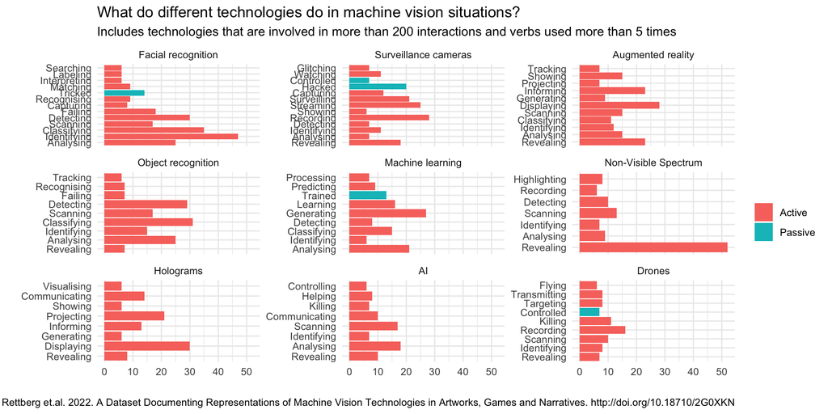

```r
Situations %>%
        filter(!is.na(Technology)) %>%
        select(SituationID, Genre, Technology, Verb) %>%
        group_by(Technology) %>%
        add_count(Verb, name = "VerbCount") %>%
        add_count(Technology, name = "TechCount") %>%
        mutate(VerbTense = case_when(str_detect(Verb, "ing") ~ "Active",
                                     TRUE ~ "Passive")) %>%
        filter(VerbCount > 5 & TechCount >200) %>%
        ggplot(aes(x=fct_infreq(Verb), fill = VerbTense)) +
        geom_bar() +
        labs(fill="",
             title ="What do different technologies do in machine vision situations?",
             subtitle = "Includes technologies that are involved in more than 200 interactions and verbs used more than 5 times",
             caption = "Based on Rettberg et.al. 2022. A Dataset Documenting Representations of Machine Vision Technologies in Artworks, Games and Narratives. http://doi.org/10.18710/2G0XKN",
             y = "",
             x = "") +
        theme_minimal() +
        coord_flip() +
        facet_wrap(~fct_infreq(Technology), scales="free_y")
```

## List of nine techs with most verbs

```r
tech <- Situations %>%
        filter(!is.na(Technology)) %>%
        select(SituationID, Genre, Technology, Verb) %>%
        group_by(Technology) %>%
        add_count(Verb, name = "VerbCount") %>%
        add_count(Technology, name = "TechCount") %>%
        mutate(VerbTense = case_when(str_detect(Verb, "ing") ~ "Active",
                                     TRUE ~ "Passive")) %>%
        filter(VerbCount > 5 & TechCount >200)


PopTech <- unique(tech$Technology)
```

## Looking just at drones.

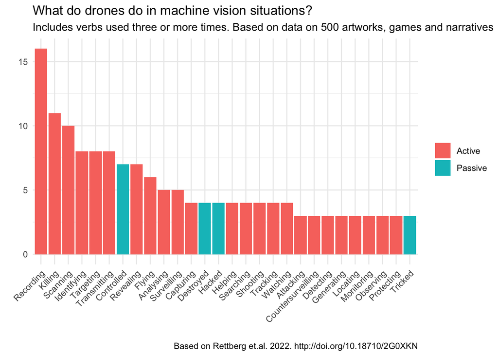

```r
Situations %>%
        filter(Technology == "Drones" & !is.na(Verb)) %>%
        select(SituationID, Genre, Technology, Verb) %>%
        add_count(Verb, name = "VerbCount") %>%
        mutate(VerbTense = case_when(str_detect(Verb, "ing") ~ "Active",
                                     TRUE ~ "Passive")) %>%
        filter(VerbCount > 2) %>%
        ggplot(aes(x=fct_infreq(Verb), fill = VerbTense)) +
        geom_bar() +
        labs(fill="",
             title ="What do drones do in machine vision situations?",
             subtitle = "Includes verbs used three or more times. Based on data on 500 artworks, games and narratives",
             caption = "Based on Rettberg et.al. 2022. http://doi.org/10.18710/2G0XKN",
             y = "",
             x = "") +
        theme_minimal() +
        theme(axis.text.x = element_text(angle=45, vjust=1, hjust = 1))
```

## Does genre affect how drones are portrayed?

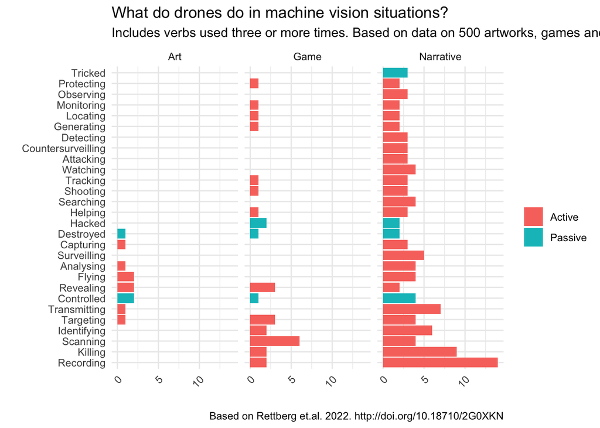

```r
Situations %>%
        filter(Technology == "Drones" & !is.na(Verb)) %>%
        select(SituationID, Genre, Technology, Verb) %>%
        add_count(Verb, name = "VerbCount") %>%
        mutate(VerbTense = case_when(str_detect(Verb, "ing") ~ "Active",
                                     TRUE ~ "Passive")) %>%
        filter(VerbCount > 2) %>%
        ggplot(aes(x=fct_infreq(Verb), fill = VerbTense)) +
        geom_bar() +
        labs(fill="",
             title ="What do drones do in machine vision situations?",
             subtitle = "Includes verbs used three or more times. Based on data on 500 artworks, games and narratives",
             caption = "Based on Rettberg et.al. 2022. http://doi.org/10.18710/2G0XKN",
             y = "",
             x = "") +
        theme_minimal() +
        theme(axis.text.x = element_text(angle=45, vjust=1, hjust = 1)) +
        coord_flip() +
        facet_wrap(~Genre)
```

## What characterises creative works with drones?

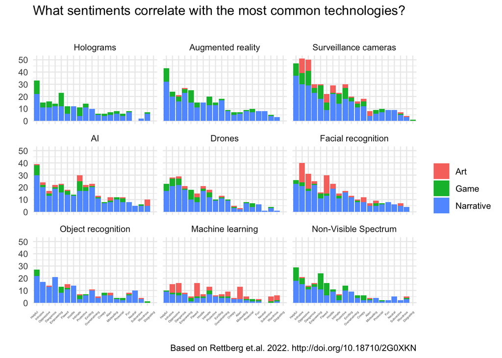

```r
#Find the techs that use drones.

Sentiments_by_freq <- CreativeWorks %>%
        select(WorkID, Sentiment) %>%
        filter(!is.na(Sentiment)) %>%
        distinct() %>%
        count(Sentiment, sort = TRUE) %>%
        slice(1:18)


CreativeWorks %>%
        filter(TechRef %in% PopTech) %>%
        select(WorkID, TechRef, Sentiment, Genre) %>%
        filter(!is.na(Sentiment)) %>%
        distinct() %>%
        ggplot(aes(x=fct_infreq(Sentiment), fill = Genre)) +
        geom_bar() +
               labs(fill="",
             title ="What sentiments correlate with the most common technologies?",
             subtitle = "",
             caption = "Based on Rettberg et.al. 2022. http://doi.org/10.18710/2G0XKN",
             y = "",
             x = "") +
        theme_minimal() +
        #theme(axis.text.y = element_text(size = 5)) +
        theme(axis.text.x = element_text(angle=45, vjust=1, hjust = 1, size = 3)) +

        #coord_flip() +
        facet_wrap(~TechRef)
```

## Sentiments simplified

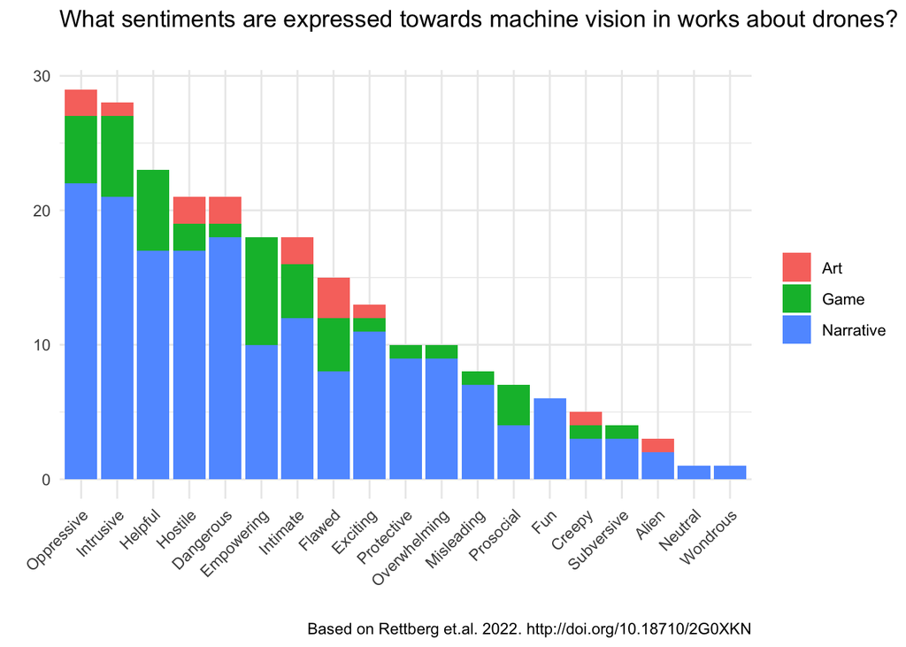

```r
CreativeWorks %>%
        filter(TechRef=="Drones") %>%
        select(WorkID, Sentiment, Genre) %>%
        filter(!is.na(Sentiment)) %>%
        distinct() %>%
        ggplot(aes(x=fct_infreq(Sentiment), fill = Genre)) +
        geom_bar() +
               labs(fill="",
             title ="What sentiments are expressed towards machine vision in works about drones?",
             subtitle = "",
             caption = "Based on Rettberg et.al. 2022. http://doi.org/10.18710/2G0XKN",
             y = "",
             x = "") +
        theme_minimal() +
        #theme(axis.text.y = element_text(size = 5)) +
        theme(axis.text.x = element_text(angle=45, vjust=1, hjust = 1))
```

```r
        #coord_flip() +
        #facet_wrap(~TechRef)
```

While helpful is the most common sentiment overall, works with drones are more oppressive and intrusive.

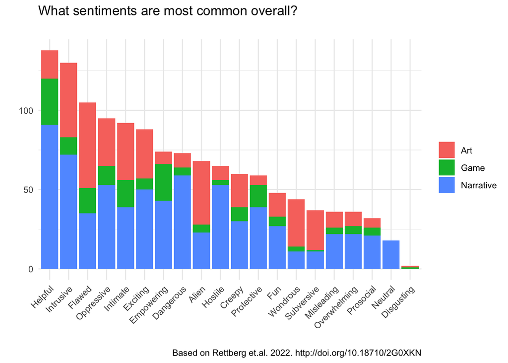

```r
CreativeWorks %>%
        select(WorkID, Sentiment, Genre) %>%
        filter(!is.na(Sentiment)) %>%
        distinct() %>%
        ggplot(aes(x=fct_infreq(Sentiment), fill = Genre)) +
        geom_bar() +
               labs(fill="",
             title ="What sentiments are most common overall?",
             subtitle = "",
             caption = "Based on Rettberg et.al. 2022. http://doi.org/10.18710/2G0XKN",
             y = "",
             x = "") +
        theme_minimal() +
        theme(axis.text.x = element_text(angle=45, vjust=1, hjust = 1))
```

Topics more likely to be associated with drones

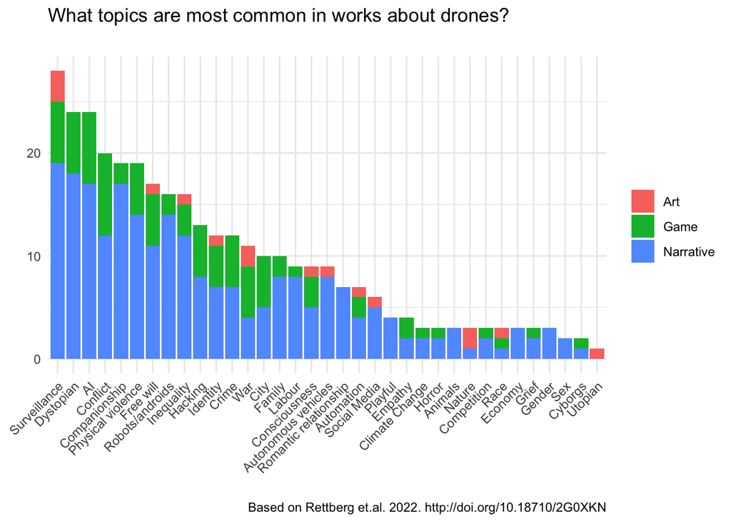

```r
CreativeWorks %>%
        filter(TechRef=="Drones") %>%
        select(WorkID, Topic, Genre) %>%
        filter(!is.na(Topic)) %>%
        distinct() %>%
        ggplot(aes(x=fct_infreq(Topic), fill = Genre)) +
        geom_bar() +
               labs(fill="",
             title ="What topics are most common in works about drones?",
             subtitle = "",
             caption = "Based on Rettberg et.al. 2022. http://doi.org/10.18710/2G0XKN",
             y = "",
             x = "") +
        theme_minimal() +
        #theme(axis.text.y = element_text(size = 5)) +
        theme(axis.text.x = element_text(angle=45, vjust=1, hjust = 1))
```

```r
        #coord_flip() +
        #facet_wrap(~TechRef)
```

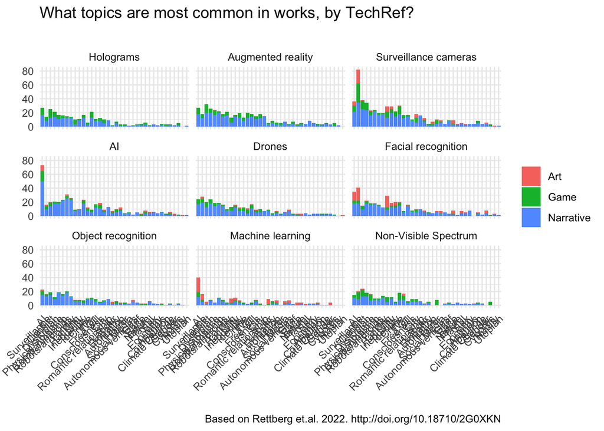

```r
CreativeWorks %>%
        filter(TechRef %in% PopTech) %>%
        select(WorkID, TechRef, Topic, Genre) %>%
        filter(!is.na(Topic)) %>%
        distinct() %>%
        ggplot(aes(x=fct_infreq(Topic), fill = Genre)) +
        geom_bar() +
               labs(fill="",
             title ="What topics are most common in works, by TechRef?",
             subtitle = "",
             caption = "Based on Rettberg et.al. 2022. http://doi.org/10.18710/2G0XKN",
             y = "",
             x = "") +
        theme_minimal() +
        #theme(axis.text.y = element_text(size = 5)) +
        theme(axis.text.x = element_text(angle=45, vjust=1, hjust = 1)) +
        facet_wrap(~TechRef)
```

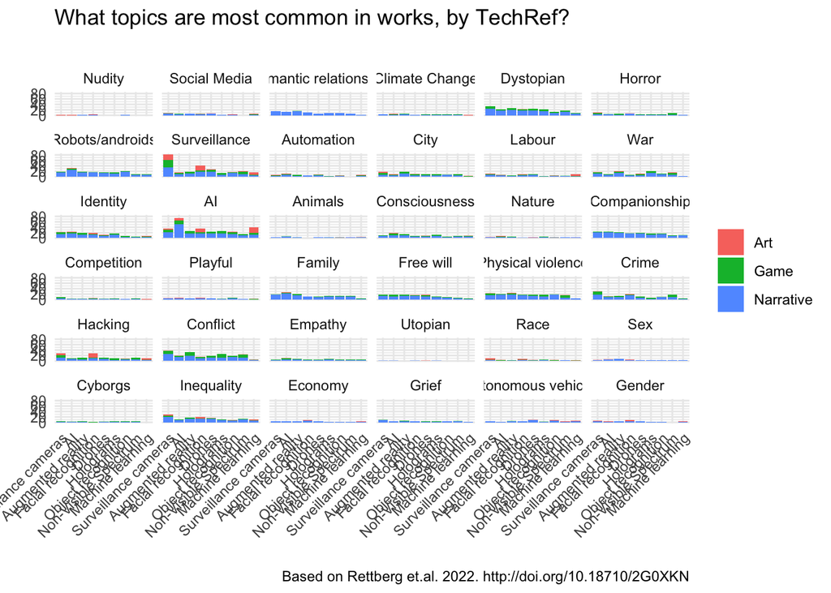

```r
CreativeWorks %>%
        filter(TechRef %in% PopTech) %>%
        select(WorkID, TechRef, Topic, Genre) %>%
        filter(!is.na(Topic)) %>%
        distinct() %>%
        ggplot(aes(x=fct_infreq(TechRef), fill = Genre)) +
        geom_bar() +
               labs(fill="",
             title ="What topics are most common in works, by TechRef?",
             subtitle = "",
             caption = "Based on Rettberg et.al. 2022. http://doi.org/10.18710/2G0XKN",
             y = "",
             x = "") +
        theme_minimal() +
        #theme(axis.text.y = element_text(size = 5)) +
        theme(axis.text.x = element_text(angle=45, vjust=1, hjust = 1)) +
        facet_wrap(~Topic)
```

## Most common topics overall

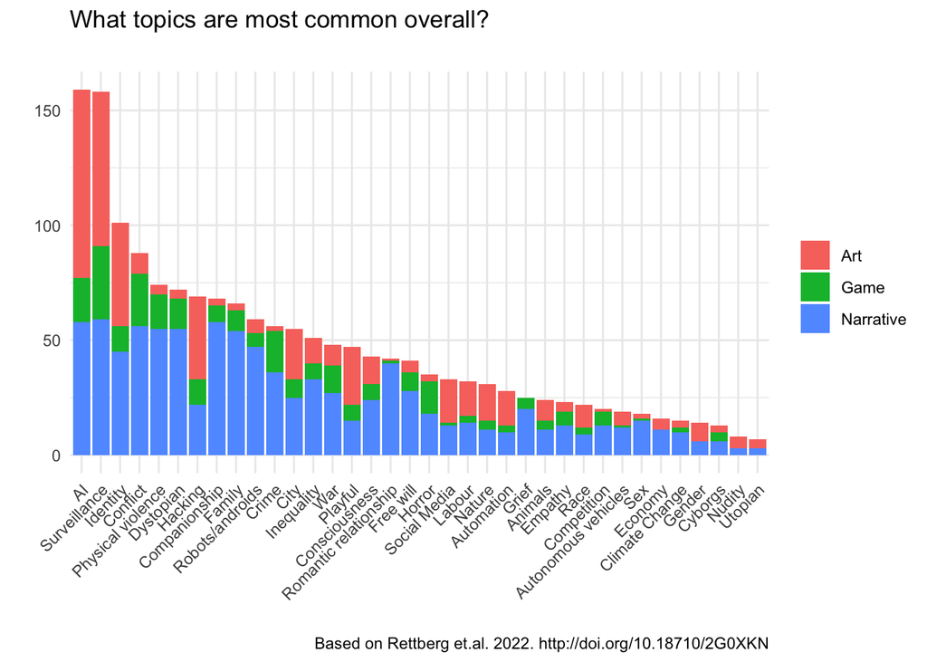

```r
CreativeWorks %>%
        select(WorkID, Topic, Genre) %>%
        filter(!is.na(Topic)) %>%
        distinct() %>%
        ggplot(aes(x=fct_infreq(Topic), fill = Genre)) +
        geom_bar() +
               labs(fill="",
             title ="What topics are most common overall?",
             subtitle = "",
             caption = "Based on Rettberg et.al. 2022. http://doi.org/10.18710/2G0XKN",
             y = "",
             x = "") +
        theme_minimal() +
        #theme(axis.text.y = element_text(size = 5)) +
        theme(axis.text.x = element_text(angle=45, vjust=1, hjust = 1))
```

## What is typical of characters who are in situations involving drones?

The following doesn’t quite work. My goal is to get a file that says

1. holograms - Leia
2. holograms - Han Solo
3. holograms - C-3PO
4. augmented reality - John the Savage

etc..

Then do a visualisation comparing what traits characters who interact with drones have compared to the traits of characters who interact with other technologies.

Perhaps network analysis is better for this?

```r
 sitID_char <- Situations %>%
         select(SituationID, Character) %>%
         filter(!is.na(Character))

 sitID_tech <- Situations %>%
         select(SituationID, Technology) %>%
         filter(!is.na(Technology))

 merge(sitID_char, sitID_tech)
```

| SituationID | Character | Technology |
| --- | --- | --- |
| 243 | Winston Smith | Surveillance cameras |
| 243 | Winston Smith | Surveillance cameras |
| 243 | Winston Smith | Surveillance cameras |
| 243 | Winston Smith | Surveillance cameras |
| 243 | Winston Smith | Surveillance cameras |
| 243 | Winston Smith | Surveillance cameras |
| 243 | Winston Smith | Surveillance cameras |
| 243 | Winston Smith | Surveillance cameras |
| 243 | Winston Smith | Surveillance cameras |
| 243 | Winston Smith | Surveillance cameras |

[output cut: 9990 more lines]

How many situations have drones in them?

```r
Situations %>%
        select(Situation, Technology) %>%
        filter(Technology == "Drones") %>%
        select(Situation) %>%
        distinct()
```

| Situation |
| --- |
| Borderlands 3 (SNTL drone) |
| No More Selfies (Drone attack) |
| Attack Surface (Drones surveilling protest) |
| Remote Control (Sankofa kills drone) |
| Attack Surface (Drone brings wedding gift) |
| Machinehood (microdrones) |
| Half-Life 2 (City drone briefly blinding protagonist) |
| Revolt (Viewer is unable to revolt) |
| Mass Effect: Andromeda (Alien mimics hologram of human) |
| The Salvage Crew (Spying on human crew) |

[output cut: 69 more lines]

How many situations are there for each of the different technologies?

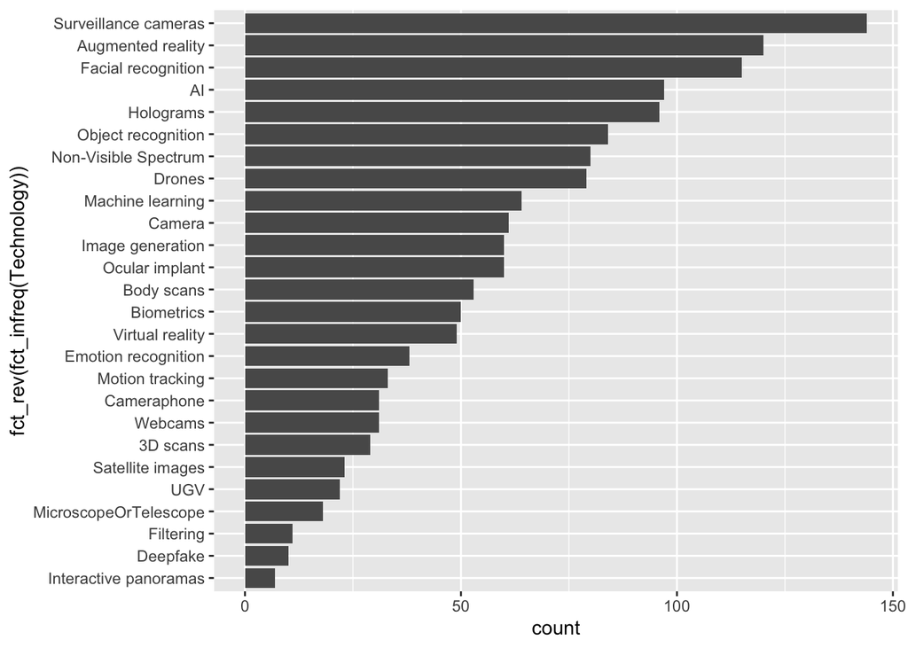

```r
Situations %>%
        select(Situation, Technology) %>%
        filter(!is.na(Technology)) %>%
        distinct() %>%
        ggplot(aes(x = fct_rev(fct_infreq(Technology)))) +
        geom_bar() +
                coord_flip()
```

# Character traits related to drones

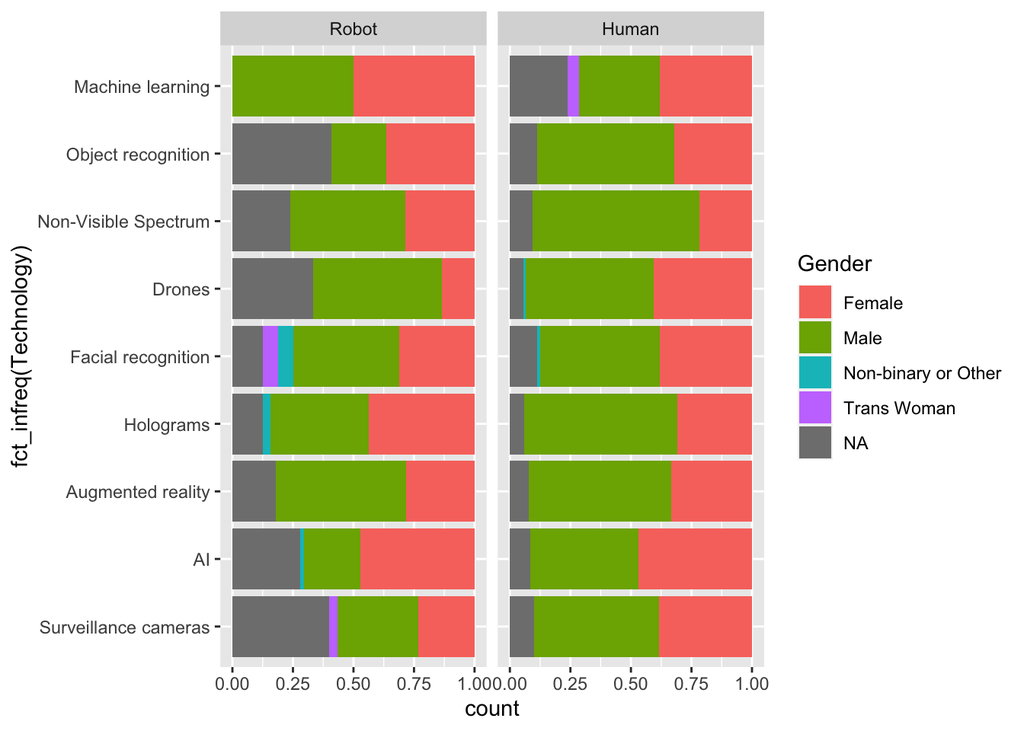

```r
sitID_char <- Situations %>%
         select(SituationID, Character) %>%
         filter(!is.na(Character)) %>%
        distinct()

sitID_tech <- Situations %>%
         select(SituationID, Technology) %>%
         filter(!is.na(Technology)) %>%
        distinct()

SitCharTech <- merge(sitID_char, sitID_tech)

TechChar <- merge(SitCharTech, Characters)

TechChar %>%
        filter(Technology %in% PopTech) %>%
        filter(Species == "Human" | Species == "Robot") %>%
        ggplot(aes(x=fct_infreq(Technology), fill=Gender)) +
        geom_bar(position="fill") +
        coord_flip() +
        facet_wrap(~Species)
```

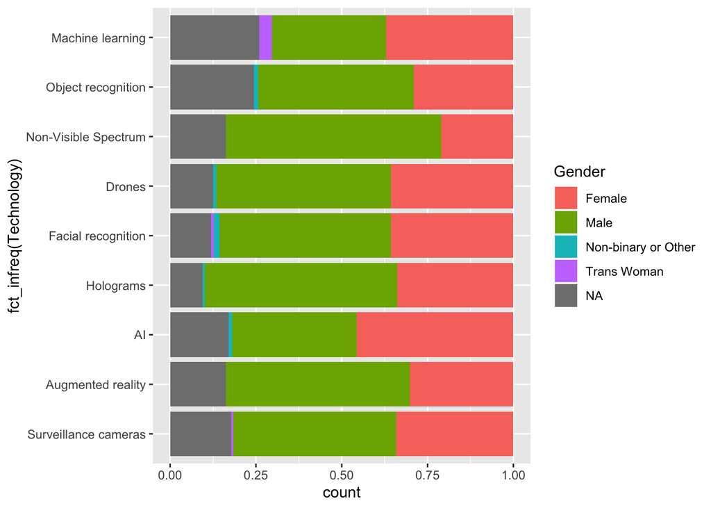

```r
TechChar %>%
        filter(Technology %in% PopTech) %>%
        ggplot(aes(x=fct_infreq(Technology), fill=Gender)) +
        geom_bar(position="fill") +
        coord_flip()
```

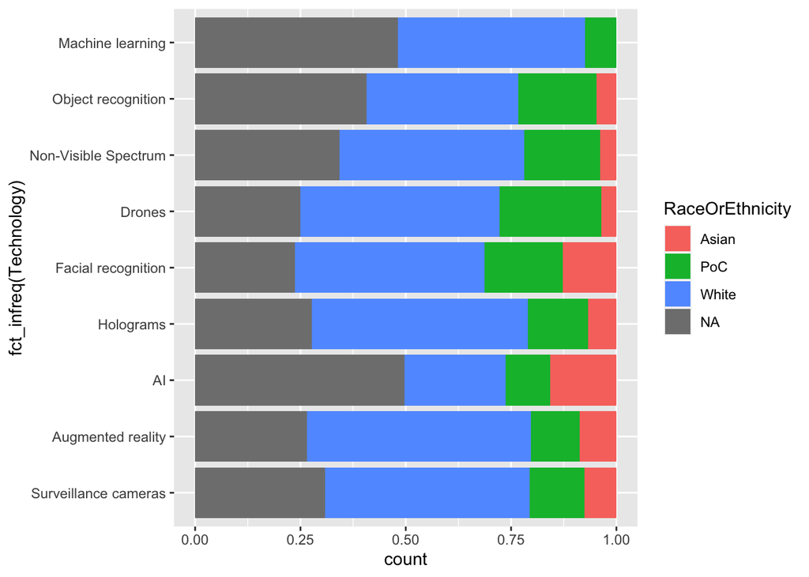

```r
TechChar %>%
    filter(Technology %in% PopTech) %>%
        ggplot(aes(x=fct_infreq(Technology), fill=RaceOrEthnicity)) +
        geom_bar(position="fill") +
        coord_flip()
```

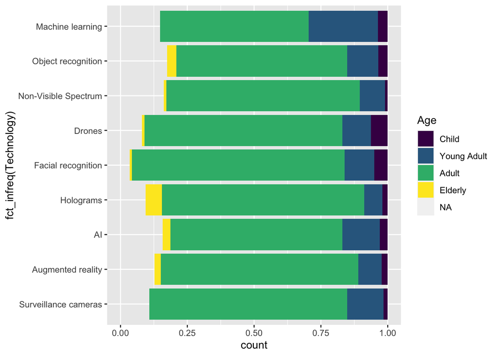

```r
TechChar %>%
    filter(Technology %in% PopTech) %>%
        ggplot(aes(x=fct_infreq(Technology), fill=Age)) +
        geom_bar(position="fill") +
        coord_flip()
```

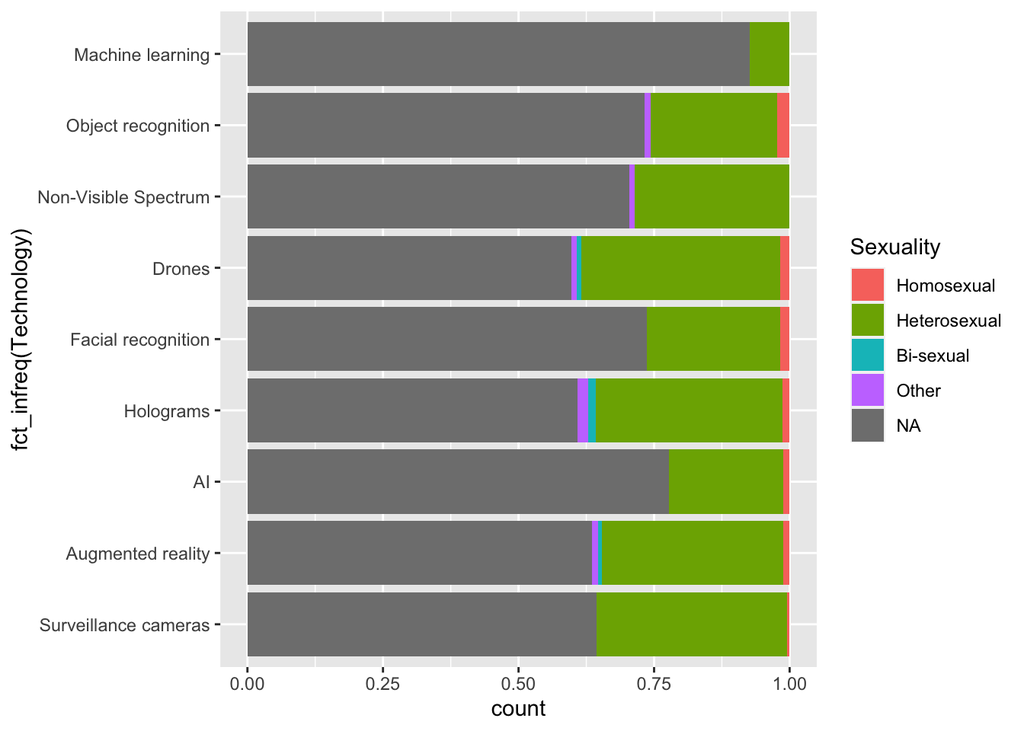

```r
TechChar %>%
    filter(Technology %in% PopTech) %>%
        ggplot(aes(x=fct_infreq(Technology), fill=Sexuality)) +
        geom_bar(position="fill") +
        coord_flip()
```

# Network analysis

```r
suppressMessages(library(RColorBrewer))
suppressMessages(library(igraph))
suppressMessages(library(multiplex))
library(ggraph)
library(graphlayouts)

nodes_chars <- Characters %>%
        select(Title = Character, Species, Gender,
               Race = RaceOrEthnicity, Age, Sexuality) %>%
        add_column(NodeType = "Character")

# To make the node table for technologies we need to return to Situations.
nodes_tech <- Situations %>%
        select(Title = Technology) %>%
        filter(!is.na(Title)) %>%
        distinct() %>%
        add_column(NodeType = "Tech",
                   Species = NA,
                   Gender = NA,
                   Race = NA,
                   Age = NA,
                   Sexuality = NA)

nodes <- rbind(nodes_chars, nodes_tech)



# Create edge table that links a character and a technology when they are in the same
# situation by making two dataframes, one with just SituationIDs and characters and one
# with just SituationIDs and Technologies, then merge them so you get Characters and
# Techs in the same row.

sitID_char <- Situations %>%
         select(SituationID, Character) %>%
         filter(!is.na(Character)) %>%
        distinct()

sitID_tech <- Situations %>%
         select(SituationID, Technology) %>%
         filter(!is.na(Technology)) %>%
        distinct()

temp <- merge(sitID_char, sitID_tech)

edges <- temp %>%
        select(From = Technology,
               To = Character,
               SituationID) %>%
        add_column(EdgeType = "In_same_situation")

# set the seed, create a graph object from the dataframe object
set.seed(123)

net <- graph_from_data_frame(d=edges, vertices=nodes, directed=T)

# Plotting this is a mess. Trying something different.

## Add the "type" attribute to the network.
V(net)$type <- bipartite_mapping(net)$type

bipartite_matrix <- as_incidence_matrix(net)
head(bipartite_matrix)
```

```
##                  Holograms Augmented reality Ocular implant Emotion recognition
## Patrick (Sight)          0                 2              0                   1
## Daphne W (Sight)         0                 2              0                   1
## Jason Hatta              0                 1              0                   0
## Regina                   0                 1              0                   0
## Emily                    0                 2              0                   0
## A2                       0                 0              0                   0
##                  Surveillance cameras AI Virtual reality Motion tracking
## Patrick (Sight)                     0  0               0               0
## Daphne W (Sight)                    0  0               0               0
## Jason Hatta                         0  0               0               0
## Regina                              0  1               0               0
## Emily                               1  1               0               0
## A2                                  0  1               1               0
##                  Body scans Drones MicroscopeOrTelescope Biometrics
## Patrick (Sight)           0      0                     0          0
## Daphne W (Sight)          0      0                     0          0
## Jason Hatta               0      0                     0          0
## Regina                    0      0                     0          0
## Emily                     0      0                     0          0
## A2                        0      0                     0          0
##                  Image generation Facial recognition Object recognition
## Patrick (Sight)                 0                  0                  0
## Daphne W (Sight)                0                  0                  0
## Jason Hatta                     0                  0                  0
## Regina                          0                  0                  0
## Emily                           0                  0                  0
## A2                              0                  0                  0
##                  3D scans Machine learning Filtering Deepfake Cameraphone
## Patrick (Sight)         0                0         0        0           0
## Daphne W (Sight)        0                0         0        0           0
## Jason Hatta             0                0         0        0           0
## Regina                  0                0         0        0           0
## Emily                   0                0         0        0           0
## A2                      0                0         0        0           0
##                  Camera Interactive panoramas Non-Visible Spectrum UGV Webcams
## Patrick (Sight)       0                     0                    0   0       0
## Daphne W (Sight)      0                     0                    0   0       0
## Jason Hatta           0                     0                    0   0       0
## Regina                0                     0                    0   0       0
## Emily                 0                     0                    0   0       0
## A2                    0                     0                    0   0       0
##                  Satellite images
## Patrick (Sight)                 0
## Daphne W (Sight)                0
## Jason Hatta                     0
## Regina                          0
## Emily                           0
## A2                              0
```

```r
# ggraph(net, layout="stress") +
#        geom_edge_fan(color="gray50", width=0.2, alpha=0.5) +
#        geom_node_point(color="orange", size=degree(net)*0.2) +
#        ggtitle("Bipartite Character/Verb network - only verbs are labelled") +
#        geom_node_text(aes(label = label), color="black", repel = T) +
#        theme_void()
```